# 2_Principal con optimizacion

## Tabla de Contenidos

</br>3.1.1. Preparar la matriz de _features_ y el vector _target_ </br>3.1.1. Optimizando el valor de _k_ </br>3.1.2. Matriz de confusión </br>3.1.3. Conclusión

# **1. Importación de *modules***

```python
import numpy as np
import pandas as pd

import seaborn as sns
import matplotlib.pyplot as plt
import plotly.express as px

from sklearn import metrics

from sklearn import tree
from sklearn.linear_model import LogisticRegression
from sklearn.naive_bayes import MultinomialNB

from sklearn.model_selection import GridSearchCV,train_test_split,cross_val_score, KFold
from sklearn.model_selection import StratifiedKFold
from sklearn.model_selection import RandomizedSearchCV
from sklearn.neighbors import KNeighborsClassifier


from sklearn.metrics import confusion_matrix, accuracy_score ,f1_score ,classification_report , confusion_matrix , roc_auc_score
from sklearn.preprocessing import normalize, StandardScaler


from IPython.core.interactiveshell import InteractiveShell
InteractiveShell.ast_node_interactivity = "all"
%config Completer.use_jedi = False
import warnings
warnings.filterwarnings("ignore")

import funciones as f
import time

!pip install graphviz
!pip install pydotplus

from IPython.display import Image
import pydotplus
```

*Variables generales*

```python
_random_state=40
tic_general = time.time()
```

# **2. Importación del dataset patient_covid.csv**

```python
data_covid = pd.read_csv("../data/patient_covid.csv", sep = ",", low_memory=False)
f._get_info(data_covid)
```

```
(95244, 29)
```

|  | inpatient | agegroup_10-19 | agegroup_20-29 | agegroup_30-39 | agegroup_40-49 | agegroup_50-59 | agegroup_60-69 | agegroup_70-79 | agegroup_80-89 | agegroup_90-99 | ... | diabetes_Y | hypertension_Y | immunosuppression_Y | obesity_Y | other_diseases_NOA | other_diseases_Y | pneumonia_Y | pregnant_Y | sex_M | smoker_Y |
| --- | --- | --- | --- | --- | --- | --- | --- | --- | --- | --- | --- | --- | --- | --- | --- | --- | --- | --- | --- | --- | --- |
| 0 | 0 | 0 | 0 | 0 | 1 | 0 | 0 | 0 | 0 | 0 | ... | 0 | 0 | 0 | 0 | 0 | 0 | 0 | 0 | 1 | 0 |
| 1 | 0 | 0 | 0 | 0 | 0 | 1 | 0 | 0 | 0 | 0 | ... | 0 | 0 | 0 | 0 | 0 | 0 | 0 | 0 | 0 | 0 |
| 2 | 1 | 0 | 0 | 0 | 0 | 1 | 0 | 0 | 0 | 0 | ... | 1 | 1 | 0 | 1 | 0 | 0 | 0 | 0 | 1 | 0 |

3 rows × 29 columns

# **3.Machine Learning Algorithms**

## **3.1. Preparar la matriz de *features* y el vector *target y Train-test***

```python
data_covid['inpatient'].value_counts(normalize=True)
```

```
0    0.734629
1    0.265371
Name: inpatient, dtype: float64
```

```python
X = data_covid.drop(["inpatient"],axis=1)
y = data_covid['inpatient']
#f._get_info(X)
```

```python
X_train, X_test, y_train, y_test = train_test_split(X, y, test_size=0.4, stratify=data_covid['inpatient'],random_state=_random_state)
display(y_train.value_counts(normalize=True).round(3))
display(y_test.value_counts(normalize=True).round(3))

print ("X_train:" , X_train.shape[0])
print ("y_train:" , y_train.shape[0])
print ("X_test:" , X_test.shape[0])
print ("y_test:" , y_test.shape[0])
```

```
0    0.735
1    0.265
Name: inpatient, dtype: float64
```

```
0    0.735
1    0.265
Name: inpatient, dtype: float64
```

```
X_train: 57146
y_train: 57146
X_test: 38098
y_test: 38098
```

## **3.2 Modelos con parámetros por defecto**

### 3.2.1 Entrenamiento y Scoring

```python
#Naive Bayes
nb=MultinomialNB()
nb.fit(X_train, y_train)
y_pred_nb = nb.predict(X_test)
score_nb = accuracy_score(y_test,y_pred_nb).round(4)

#Tree Classification
clftree = tree.DecisionTreeClassifier(random_state=_random_state)
clftree.fit(X_train, y_train)
y_pred_t = clftree.predict(X_test)
score_t = accuracy_score(y_test, y_pred_t).round(4)

#--------scaler -----------
#scaler = StandardScaler()
#X_train_std = scaler.fit_transform(X_train)
#X_test_std = scaler.transform(X_test)

#KNN (acá no especificamos n_neighbors y queda el que viene por defecto)
knn = KNeighborsClassifier()
knn.fit(X_train, y_train)
y_pred_knn = knn.predict(X_test)
score_knn=accuracy_score(y_test, y_pred_knn).round(4)

#Logistic regression (con StandarScaler)
lr = LogisticRegression(class_weight="balance")
lr.fit(X_train, y_train)
y_pred_lr = lr.predict(X_test)
score_lr= accuracy_score(y_test, y_pred_lr).round(4)

#Scores
print ("Naive Bayes Acc Score:    \t",score_nb)
print ("KNN Acc Score:\t\t\t", score_knn)
print ("Logistic Regression Acc Score:  ", score_lr)
print ("Tree classification Acc Score:  ", score_t)
```

```
MultinomialNB()
```

```
DecisionTreeClassifier(random_state=40)
```

```
KNeighborsClassifier()
```

```
LogisticRegression(class_weight='balance')
```

```
Naive Bayes Acc Score:    	 0.8503
KNN Acc Score:			 0.8621
Logistic Regression Acc Score:   0.8738
Tree classification Acc Score:   0.8664
```

### 3.2.2 Confusion_matrix

[figure not shown]

```python
print ("X_test:" , X_test.shape[0])
print ("y_test:" , y_test.shape[0])
print("CM NB:\n", confusion_matrix(y_test, y_pred_nb))
print("CM KNN:\n",confusion_matrix(y_test, y_pred_knn))
print("CM LR:\n", confusion_matrix(y_test, y_pred_lr))
print("T LR:\n",  confusion_matrix(y_test, y_pred_t))
```

```
X_test: 38098
y_test: 38098
CM NB:
 [[26012  1976]
 [ 3727  6383]]
CM KNN:
 [[26175  1813]
 [ 3439  6671]]
CM LR:
 [[26805  1183]
 [ 3625  6485]]
T LR:
 [[26652  1336]
 [ 3754  6356]]
```

```
[[0.6828 0.0519]
 [0.0978 0.1675]]
```

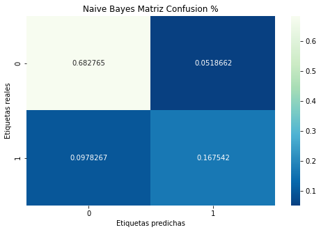

```python
f._print_matriz_confusion(y_test, y_pred_nb,"Naive Bayes Matriz Confusion %", 'all')
```

```
[[0.687  0.0476]
 [0.0903 0.1751]]
```

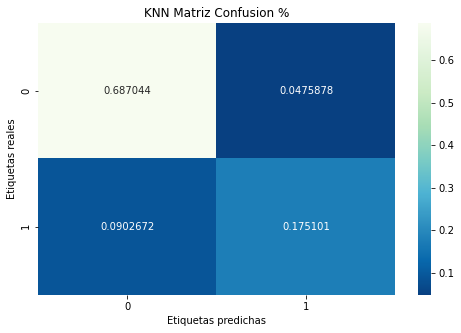

```python
f._print_matriz_confusion(y_test, y_pred_knn,"KNN Matriz Confusion %", 'all')
```

```
[[0.7036 0.0311]
 [0.0951 0.1702]]
```

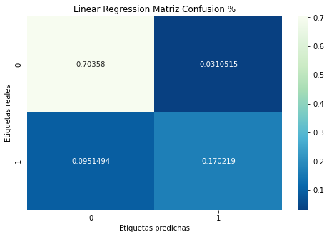

```python
f._print_matriz_confusion(y_test, y_pred_lr,"Linear Regression Matriz Confusion %", 'all')
```

```
[[0.6996 0.0351]
 [0.0985 0.1668]]
```

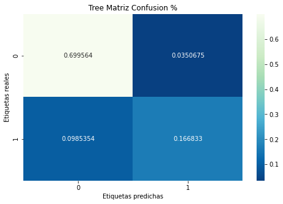

```python
f._print_matriz_confusion(y_test, y_pred_t,"Tree Matriz Confusion %", 'all')
```

### 3.2.3 Recall, Precision and F-1 Score

- Recall = TP / (TP + FN)
- Precision = TP / (TP + FP)
- F-Measure = (2 *Precision* Recall) / (Precision + Recall)

```python
print("NB:\n", classification_report(y_test,y_pred_nb))
print("KNN:\n", classification_report(y_test,y_pred_knn))
print("LR:\n", classification_report(y_test,y_pred_lr))
print("T:\n", classification_report(y_test,y_pred_t))
```

```
NB:
               precision    recall  f1-score   support

           0       0.87      0.93      0.90     27988
           1       0.76      0.63      0.69     10110

    accuracy                           0.85     38098
   macro avg       0.82      0.78      0.80     38098
weighted avg       0.85      0.85      0.85     38098

KNN:
               precision    recall  f1-score   support

           0       0.88      0.94      0.91     27988
           1       0.79      0.66      0.72     10110

    accuracy                           0.86     38098
   macro avg       0.84      0.80      0.81     38098
weighted avg       0.86      0.86      0.86     38098

LR:
               precision    recall  f1-score   support

           0       0.88      0.96      0.92     27988
           1       0.85      0.64      0.73     10110

    accuracy                           0.87     38098
   macro avg       0.86      0.80      0.82     38098
weighted avg       0.87      0.87      0.87     38098

T:
               precision    recall  f1-score   support

           0       0.88      0.95      0.91     27988
           1       0.83      0.63      0.71     10110

    accuracy                           0.87     38098
   macro avg       0.85      0.79      0.81     38098
weighted avg       0.86      0.87      0.86     38098
```

```python
print ("F1 Score NB: ", f1_score(y_test,y_pred_nb).round(4))
print ("F1 Score KNN:", f1_score(y_test,y_pred_knn).round(4))
print ("F1 Score LR: ", f1_score(y_test,y_pred_lr).round(4))
print ("F1 Score T:  ", f1_score(y_test,y_pred_t).round(4))
```

```
F1 Score NB:  0.6912
F1 Score KNN: 0.7175
F1 Score LR:  0.7296
F1 Score T:   0.7141
```

### 3.2.4 ROC & AUC

```python
def _metric_AUC(X_t,y_t,y_pred,modelo):  # return roc_auc,fpr,tpr,threshold
    probs=modelo.predict_proba(X_t)
    preds=probs[:,1]
    fpr,tpr,threshold=metrics.roc_curve(y_test, y_pred)
    roc_auc=metrics.auc(fpr,tpr)
    return roc_auc,fpr,tpr,threshold

# return roc_auc,fpr,tpr,threshold
#NB
roc_auc_nb,fpr_nb,tpr_nb,threshold_nb=_metric_AUC(X_test,y_test,y_pred_nb,nb)
#KNN
roc_auc_knn,fpr_knn,tpr_knn,threshold_knn=_metric_AUC(X_test,y_test,y_pred_knn,knn)
#LR
roc_auc_lr,fpr_lr,tpr_lr,threshold_lr=_metric_AUC(X_test,y_test,y_pred_lr,lr)
#T
roc_auc_t,fpr_t,tpr_t,threshold_t=_metric_AUC(X_test,y_test,y_pred_t,clftree)
print ("ROC AUC NB:  ",  roc_auc_nb.round(4))
print ("ROC AUC KNN: ", roc_auc_knn.round(4))
print ("ROC AUC LR:  ",  roc_auc_lr.round(4))
print ("ROC AUC T:   ",   roc_auc_t.round(4))
```

```
ROC AUC NB:   0.7804
ROC AUC KNN:  0.7975
ROC AUC LR:   0.7996
ROC AUC T:    0.7905
```

```
(0.0, 1.0)
```

```
(0.0, 1.0)
```

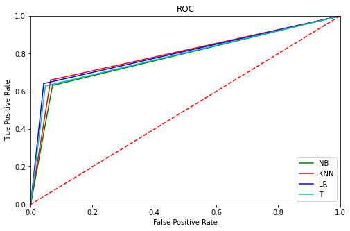

```python
plt.title("ROC")
plt.rcParams['figure.figsize'] = (19, 6)
# return roc_auc,fpr,tpr,threshold
plt.plot(fpr_nb, tpr_nb, 'g', label="NB" )
plt.plot(fpr_knn, tpr_knn, 'r', label="KNN" )
plt.plot(fpr_lr, tpr_lr, 'b', label="LR" )
plt.plot(fpr_t, tpr_t, 'c', label="T" )

plt.legend(loc="lower right")
plt.plot([0,1],[0,1],'r--')
plt.xlim([0,1])
plt.ylim([0,1])
plt.ylabel('True Positive Rate')
plt.xlabel('False Positive Rate')
plt.show()
```

## **3.3 Optimización de parámetros**

*con gridsearch random cada uno de los modelos por sparado ( sin bayes)*

### 3.3.0 config uracion general para toods los gridsearch

```python
# Definimos la estrategia de validación cruzada
kf = KFold(n_splits=2, shuffle=True, random_state=_random_state)
#folds=StratifiedKFold(n_splits=10, random_state=_random_state, shuffle=True)
_n_jobs=1
_scoring='accuracy'
grids = []
```

### *3.3.1 Tree Classification*

#### 3.3.1.1 Grafico previo a optimización

[figure not shown]

```python
dot_data= tree.export_graphviz(clftree, out_file=None,feature_names= X_train.columns, filled = True)
graph = pydotplus.graph_from_dot_data(dot_data)
Image(graph.create_png())
```

#### 3.3.1.2 GridSearch para Tree Classification

```python
_params_tree = { "criterion" : ["gini", "entropy"],
                "min_samples_leaf": [5,10,15,20,None],
                "max_depth" : [1,2,3,4,5,6,8,9,10,11,None],
                "min_samples_split": [2, 3, 4,None]}
clftree = tree.DecisionTreeClassifier(random_state=_random_state)
```

```python
grid_search_tree = GridSearchCV(estimator=clftree,
                                param_grid=_params_tree,
                                n_jobs=_n_jobs,
                                cv=kf,
                                scoring=_scoring)
fit = grid_search_tree.fit(X_train, y_train)
grids.append(fit)

print (grid_search_tree.best_score_)
print (grid_search_tree.best_params_ )
print(grid_search_tree.best_estimator_)
```

```
0.8704896230707311
{'criterion': 'entropy', 'max_depth': 10, 'min_samples_leaf': 5, 'min_samples_split': 2}
DecisionTreeClassifier(criterion='entropy', max_depth=10, min_samples_leaf=5,
                       random_state=40)
```

```
DecisionTreeClassifier(max_depth=7, min_samples_leaf=15, random_state=40)
```

[figure not shown]

```python
clftree = tree.DecisionTreeClassifier(criterion = "gini", min_samples_leaf = 15, max_depth = 7, min_samples_split = 2, random_state=_random_state)
clftree.fit(X_train, y_train)
score_t = clftree.score(X_test, y_test)

dot_data = tree.export_graphviz(clftree, out_file=None,feature_names= X_train.columns, filled = True)
graph = pydotplus.graph_from_dot_data(dot_data)
Image(graph.create_png())
```

### **3.3.2 Logistic Regression**

#### 3.3.2.1 Summary of Feature Importance

```
<BarContainer object of 28 artists>
```

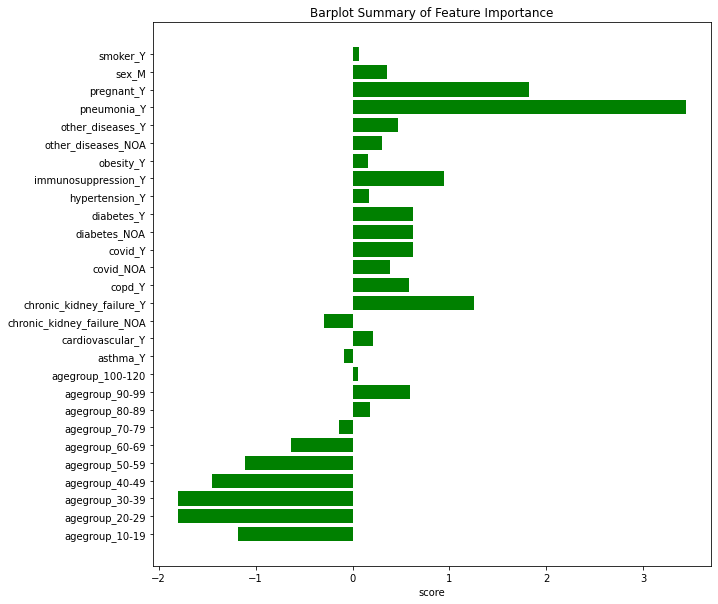

```python
importance = lr.coef_.flatten()

plt.rcParams["figure.figsize"] =(10,10)
plt.barh(X.columns,importance,color="g")
plt.title("Barplot Summary of Feature Importance")
plt.xlabel("score")
plt.show()
```

#### 3.3.2.2 Regularización

```python
#Best C
lr_reg = LogisticRegression(solver= 'liblinear', penalty='l1', C=0.01)
lr_reg.fit(X_train,y_train)
y_pred_lr_reg = lr_reg.predict(X_test)
score_lr_reg= accuracy_score(y_test, y_pred_lr_reg).round(4)
score_lr_reg
```

```
LogisticRegression(C=0.01, penalty='l1', solver='liblinear')
```

```
0.8725
```

#### 3.3.2.3 Feature importance post regularización

```
<BarContainer object of 28 artists>
```

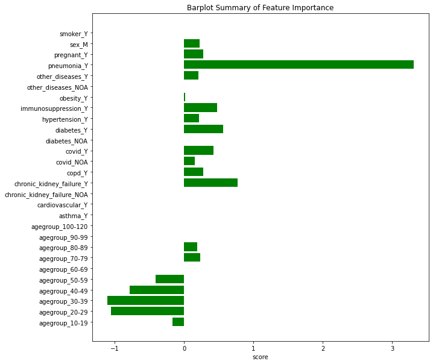

```python
importance = lr_reg.coef_.flatten()

plt.rcParams["figure.figsize"] =(10,10)
plt.barh(X.columns,importance,color="g")
plt.title("Barplot Summary of Feature Importance")
plt.xlabel("score")
plt.show()
```

#### 3.3.2.xxx Gridsearch para Logistic regression

```python
_params_LogR= {'C': [1, 10, 100, 1000],
               'penalty': ['l1', 'l2',],
               'solver': ['saga']}
_LogR = LogisticRegression()
```

```python
grid_search_LogR = GridSearchCV(estimator=_LogR,
                                param_grid=_params_LogR,
                                n_jobs=_n_jobs,
                               cv=kf,
                                scoring=_scoring)
fit = grid_search_LogR.fit(X_train, y_train)

print (grid_search_LogR.best_score_)
print (grid_search_LogR.best_params_)
print(grid_search_LogR.best_estimator_)

grids.append(fit)
```

```
0.8714695691736954
{'C': 1, 'penalty': 'l1', 'solver': 'saga'}
LogisticRegression(C=1, penalty='l1', solver='saga')
```

### **3.3.3 KNN**

#### *3.3.3.1 Optimizando el valor de k con gridsearch*

```python
_params_knn = {'n_neighbors': range(1,30),
          'weights' : ['uniform', 'distance'],
           'p' : [1, 2, 3]}
knn = KNeighborsClassifier()
```

```python
grid_search_knn = GridSearchCV(estimator=knn,
                                param_grid=_params_knn,
                                n_jobs=_n_jobs,
                               cv=kf,
                                scoring=_scoring)
fit = grid_search_knn.fit(X_train, y_train)

print (grid_search_knn.best_score_)
print (grid_search_knn.best_params_ )
print(grid_search_knn.best_estimator_)

grids.append(fit)
```

[output not shown]

### *3.3.4 Resumen de gridsearch

```python
for i in grids:
    print (i.best_score_)
    print (i.best_estimator_)
    print (i.best_params_)
```

## **3.5 Modelos con parámetros optimizados**

### *3.5.1 classification_report optimizados*

Recall, Precision and F-1 Score¶

- Recall = TP / (TP + FN)
- Precision = TP / (TP + FP)
- F-Measure = (2 *Precision* Recall) / (Precision + Recall)

```python
y_preds_tree = grids[0].predict(X_test)  # tree
y_preds_log = grids[1].predict(X_test)  # logistica
y_preds_knn = grids[2].predict(X_test)  # logistica

print("clasification tree")
print (classification_report(y_test, y_preds_log))
print("logistic regression")
print (classification_report(y_test, y_preds_log))
print("knn")
print (classification_report(y_test, y_preds_log))
```

### *3.5.2 Matriz de confusion optimizados*

```python
print("CM NB:\n", confusion_matrix(y_test, y_pred_nb))  #usando el que no lleva optimizacion
print("CM KNN:\n",confusion_matrix(y_test, y_pred_knn))
print("CM LogR:\n", confusion_matrix(y_test, y_preds_log))
print("CM TREE:\n",  confusion_matrix(y_test, y_preds_tree))
```

```python
f._print_matriz_confusion(y_test, y_pred_nb,"Naive Bayes Matriz Confusion %", 'all')
f._print_matriz_confusion(y_test, y_pred_knn,"KNN Matriz Confusion %", 'all')
f._print_matriz_confusion(y_test, y_preds_log,"Log regresion Matriz Confusion %", 'all')
f._print_matriz_confusion(y_test, y_preds_tree,"Clasificacion tree Matriz Confusion %", 'all')
```

### 3.4.3 Recall, Precision and F-1 Score

```python
print ("F1 Score NB:", f1_score(y_test,y_pred_nb))
print ("F1 Score KNN:", f1_score(y_test,y_pred_knn))
print ("F1 Score LR:", f1_score(y_test,y_pred_lr))
print ("F1 Score T:", f1_score(y_test,y_pred_t))
```

### 3.4.4 ROC & AUC

```python
# return roc_auc,fpr,tpr,threshold
#NB
roc_auc_nb,fpr_nb,tpr_nb,threshold_nb=_metric_AUC(X_test,y_test,y_pred_nb,nb)
#KNN
roc_auc_knn,fpr_knn,tpr_knn,threshold_knn=_metric_AUC(X_test,y_test,y_pred_knn,knn)
#LR
roc_auc_lr,fpr_lr,tpr_lr,threshold_lr=_metric_AUC(X_test,y_test,y_pred_lr,lr)
#T
roc_auc_t,fpr_t,tpr_t,threshold_t=_metric_AUC(X_test,y_test,y_pred_t,clftree)

print ("ROC AUC NB:  ",  roc_auc_nb.round(4))
print ("ROC AUC KNN: ", roc_auc_knn.round(4))
print ("ROC AUC LR:  ",  roc_auc_lr.round(4))
print ("ROC AUC T:   ",   roc_auc_t.round(4))
```

[output not shown]

```python
plt.title("ROC")

plt.rcParams['figure.figsize'] = (19, 6)

plt.plot(fpr_nb, tpr_nb, 'g', label="NB" % roc_auc_nb)
plt.plot(fpr_knn, tpr_knn, 'r', label="KNN" % roc_auc_nb)
plt.plot(fpr_lr, tpr_lr, 'b', label="LR" % roc_auc_nb)
plt.plot(fpr_t, tpr_t, 'y', label="T" % roc_auc_nb)

plt.legend(loc="lower right")
plt.plot([0,1],[0,1],'r--')
plt.xlim([0,1])
plt.ylim([0,1])
plt.ylabel('True Positive Rate')
plt.xlabel('False Positive Rate')
plt.show()
```

# **4.Conclusiones**

```python
toc_general = time.time()
print(str(toc-tic) + ' Segundos todo el notebook')
```

Optimización:

- LR: feature selection con penalización y tuneo de C
- Tree: GridSearchCV de best params
- Knn: GridSearchCV de best params

[output not shown]

Respecto de los resultados de cada modelo:

[output not shown]

[output not shown]

| CM LogR: |  |  |
| --- | --- | --- |
|  | N | P |

N|27008| 980| P|3922 | 6188|

| CM Tree: |  |  |
| --- | --- | --- |
|  | N | P |

N|26831 | 1157| P|3702 |6408|

El Modelo que más redujo el componente económico (FP) es LR El modelo que más redujo el componente judicial (FN) es Tree

El modelo que más acertó los TP y TN es (sacando Bayes) Tree